# Bruhn_A23_2

### 例題3

図 A23.13 は、A8.7ページで議論された単一ベイのピン接合トラスを示している。

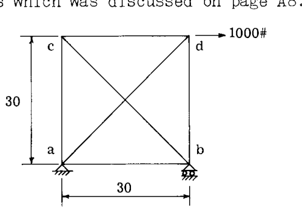

Fig. A23.13

このトラスを、ガウス消去法を用いた変位法によって解決する。解決の初期ステップは、システム剛性マトリクスをコンパイルすることである。必要な要素情報は、以下の表にまとめられている。

#### 表 A23.3

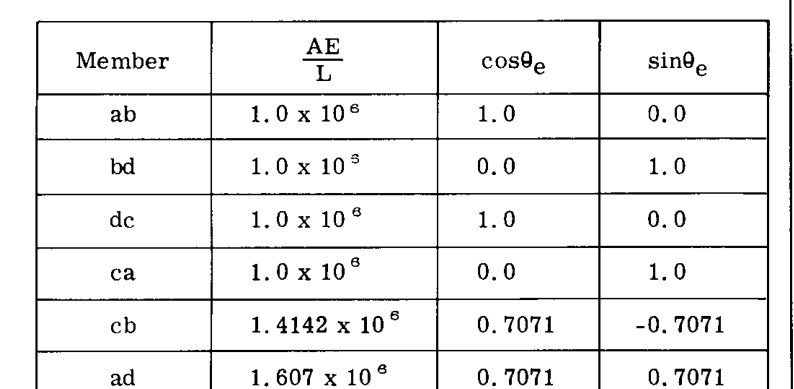

Table A23.3

全体（システム） $x$ 軸と部材の構造軸との間の角度が $\theta$ であることに注意されたい。

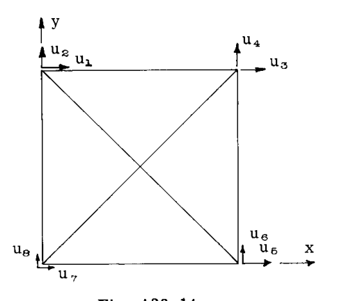

Fig. A23.14

要素の変換マトリクスは、以下のように与えられる。

$$[\beta_e] = \begin{bmatrix} \cos \theta_e & \sin \theta_e \\ -\sin
\theta_e & \cos \theta_e \end{bmatrix}$$
(50)

そして、システム全体の剛性マトリクスは、

$$[K] = 10^6 \begin{bmatrix} 1.7071 & -0.7071 & -1 & 0 &
-0.7071 & 0.7071 & 0 & 0 \\ & 1.7071 & 0 & 0
& 0.7071 & -0.7071 & 0 & -1 \\ & & 1.5303 &
0.5303 & 0 & 0 & -0.5303 & -0.5303 \\ & & &
1.5303 & 0 & -1 & -0.5303 & -0.5303 \\ & & &
& 1.7071 & -0.7071 & -1 & 0 \\ & \text{Symmetrical}
& & & & 1.7071 & 0 & 0 \\ & & &
& & & 1.5303 & 0.5303 \\ & & & & &
& & 1.5303 \end{bmatrix}$$
(61)

式2は以下のように書き換えることができる。

$$\begin{Bmatrix} F \\ \hline R \end{Bmatrix} = \begin{bmatrix} K_{11}
& \vert & K_{12} \\ \hline K_{21} & \vert & K_{22}
\end{bmatrix} \begin{Bmatrix} u^c \\ \hline 0 \end{Bmatrix}$$
(62)

ここで、 $R$ は境界（支持条件）における力を表し、 $u^c$ は境界条件を適用した後に残るシステム座標を表す。したがって、拘束静力学問題は、単に固定された座標に対応する行と列を削除することによって得られる。この例では、すべての荷重条件に対して境界条件は $u_6 = u_7 = u_8 = 0$ である。問題の定式化は、拘束された座標を排除することで単純化され、以下のようになる。

$$\{F\} = [K_{11}] \{u^c\}$$
(63)

ここで、

$$[K_{11}] = 10^6 \begin{bmatrix} 1.7071 & -0.7071 & -1 & 0
& -0.7071 \\ -0.7071 & 1.7071 & 0 & 0 & 0.7071 \\ -1
& 0 & 1.5303 & 0.5303 & 0 \\ 0 & 0 & 0.5303
& 1.5303 & 0 \\ -0.7071 & 0.7071 & 0 & 0 &
1.7071 \end{bmatrix}$$
(64)

必要に応じて、反力は以下から求めることができる。

$$\{R\} = [K_{21}] \{u^c\} = [K_{21}] [K_{11}]^{-1} \{F\}$$
(65)

上述の解法手順は、必要に応じて支点の沈下などを考慮するように修正することができる。

変位を解くために、ガウス消去法が使用される。式57に対応する前進消去ステップの結果は、以下のマトリクス方程式となる。

$$10^6 \begin{bmatrix} 1.7071 & -0.7071 & -1 & 0 & -0.7071
\\ 0 & 1.4142 & -0.4142 & 0 & 0.4142 \\ 0 & 0 &
0.8232 & 0.5303 & -0.2929 \\ 0 & 0 & 0 & 1.1887
& 0.1887 \\ 0 & 0 & 0 & 0 & 1.1588 \end{bmatrix}
\begin{Bmatrix} u_1 \\ u_2 \\ u_3 \\ u_4 \\ u_5 \end{Bmatrix} =
\begin{Bmatrix} F_1 \\ F_2 + 0.4142 F_1 \\ F_3 + 0.2929 F_2 + 0.7071 F_1
\\ F_4 - 0.6442 F_3 - 0.1887 F_2 - 0.4555 F_1 \\ F_5 - 0.1587 F_4 +
0.4580 F_3 - 0.1588 F_2 + 0.6168 F_1 \end{Bmatrix}$$
(66)

分析対象の問題では、 $F_3$ のみが考慮される力である。したがって、後退代入プロセスの右辺は次のようになる。

$$F_3 \begin{Bmatrix} 0 \\ 0 \\ 1 \\ -0.6442 \\ 0.4580 \end{Bmatrix}$$

マトリクス方程式の各行は、未知数 $u$ に関する代数方程式を表す。これらは逆の順序で解かれ、次の結果が得られる。

$$\begin{aligned}
u_5 &= 0.3952 \times 10^{-6} F_3 \\
u_4 &= -0.6047 \times 10^{-6} F_3 \\
u_3 &= 1.7450 \times 10^{-6} F_3 \\
u_2 &= 0.3953 \times 10^{-6} F_3 \\
u_1 &= 1.3497 \times 10^{-6} F_3
\end{aligned}$$

静的たわみは、 $F_3 = 1000$ の値を代入することで求められる。

部材力は、前と同様に適切な $[\beta_e]$ および $[k_e]$ マトリクスを使用して通常の方法で決定される。結果は 図 A23.15 に示されている。

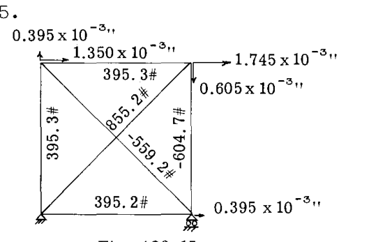

Fig. A23.15

### A23.8 ガウス・ザイデル反復法

第2の解法クラスには、反復の使用が含まれる。反復解法は、その記述が疎なマトリクス、すなわち比較的少数の非ゼロ要素を含むマトリクスをもたらす構造物に対して特に魅力的である。有限要素でモデル化された巨大な立体フレームワークや、2次元および3次元の固体がそのような構造の例である。広く使用されている反復技術の一つがガウス・ザイデル法である。この方法では、妥当な値を推測することによって、初期解ベクトルが生成される。この試行解は、評価対象以外のすべての未知数に対して現在の値を使用し、線形方程式を順次解くことによって体系的に改善される。未知数が決定されるとすぐに、サイクルが完了するのを待つのではなく、特定の反復サイクル内の後続のステップで使用される値に組み込まれる。図として、適用力 $F_1 = 24000\text{ lb}$ を持つ例題2の門型ラーメンを考える。 $EI = 10^8\text{ lb. in.}^2$ および $L = 100\text{ inches}$ の値を仮定し、ガウス・ザイデル反復法を使用してたわみを計算する。指示された代入を行い、共通因数の $8000$ で除算した後、問題は次の形式に持ち込むことができる。

$$\begin{bmatrix} 3 & 75 & -75 \\ 75 & 10000 & 2500 \\ -75
& 2500 & 10000 \end{bmatrix} \begin{Bmatrix} u_1 \\ u_2 \\ u_3
\end{Bmatrix} = \begin{Bmatrix} 3 \\ 0 \\ 0 \end{Bmatrix}$$
(67)

反復のために、各スカラー方程式の左辺に1つの未知数のみが現れるように、さらに縮小することが価値がある。この操作に続いて、解くべき方程式は次のようになる。

$$\begin{aligned}
u_1 &= 1 - 25 u_2 + 25 u_3 & (68a) \\
u_2 &= -0.0075 u_1 - 0.25 u_3 & (68b) \\
u_3 &= 0.0075 u_1 - 0.25 u_2 & (68c)
\end{aligned}$$

試行解として、横揺れが支配的なたわみになると予想されるため、 $u_1 = 1$ 、 $u_2 = u_3 = 0$ とする。手順の選択されたステップにおける結果は 表 A23.4 に示されている。収束は迅速ではないようだが、解法を加速するための方法が存在する。詳細については、数値解析のテキストを参照されたい。

#### 表 A23.4

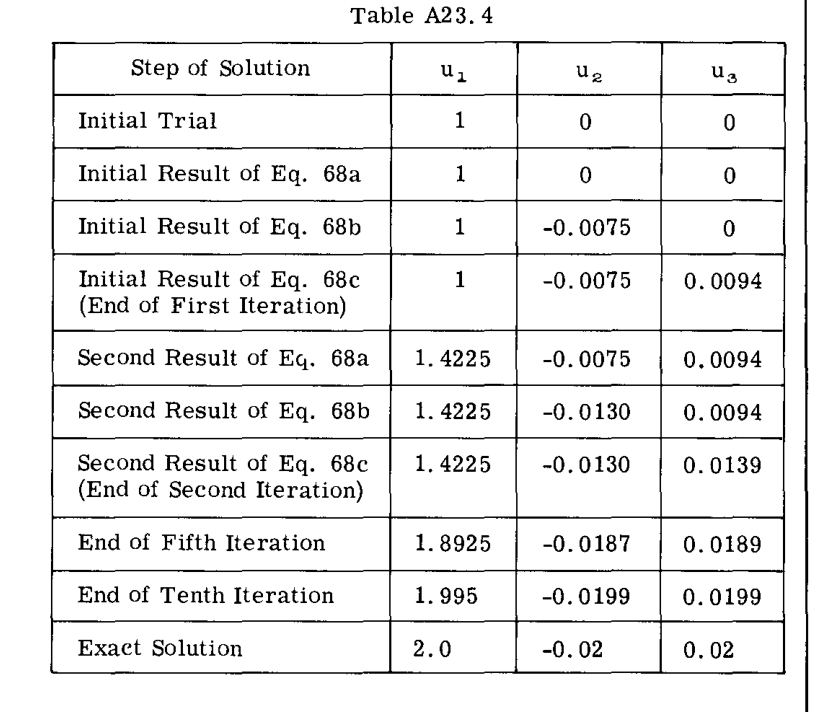

Table A23.4

### A23.9 節点間荷重に対する節点力の計算

多くの実際の状況において、構造物は節点以外の場所に荷重を受ける。もちろん、集中荷重の場合、この複雑さは荷重位置に節点を導入することによって解決できる。しかし、圧力のような分布荷重の場合、問題を回避する方法はない。したがって、有限要素の定式化と整合する等価な節点力を計算する方法を導き出したい。これを行うために、仮想仕事の原理を採用する。例として、弾性梁要素の場合を考える。各節点座標に関連して、梁の曲げ微分方程式の解から見出される、有限要素全体のたわみ形状または分布座標が存在する。これらの形状は 図 A23.16 に示されている。

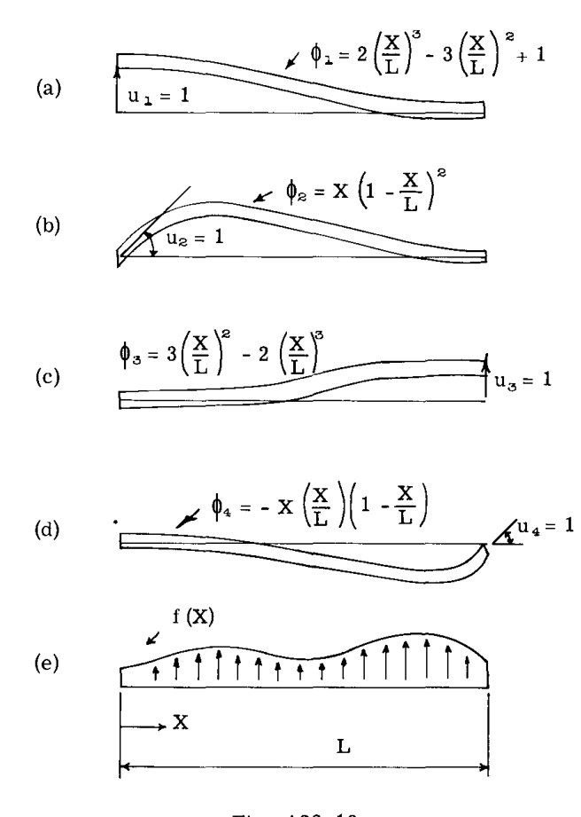

Fig. A23.16

したがって、式1から、節点座標と要素の変形形状との間の関係は、

$$w(X) = u_1 \phi_1(X) + u_2 \phi_2(X) + u_3 \phi_3(X) + u_4 \phi_4(X)$$
(69)

作用する荷重を図 A23.16e に示すように $f(X)$ とする。すると、仮想変位 $\Delta w$ を通じて作用する荷重によって生じる総仮想仕事は、

$$\Delta W = \int_0^L f(X) \Delta w(X) dX$$
(70)

または式69から代入すると、

$$\Delta W = \sum_{i=1}^4 \int_0^L f(X) \phi_i(X) dX \Delta u_i$$
(71)

同様に、総仮想仕事は、互換性のある節点仮想変位 $\Delta u_i$ を通じて作用する節点力 $P_i$ によって行われる仕事を計算することによっても与えられる。結果は、

$$\Delta W = \sum_{i=1}^4 P_i \Delta u_i$$
(72)

であり、 $\Delta u_i$ は独立であるため、式71と72の右辺は項ごとに等しくなり、目的の方程式が得られる。

$$P_i = \int_0^L f(X) \phi_i(X) dX, \quad i = 1, \dots, 4$$
(73)

節点間に作用するモーメントの場合、並行した展開により以下の結果が得られる。

$$P_i = \int_0^L m(X) \phi'_i(X) dX, \quad i = 1, \dots, 4$$
(74)

ここで、 $m(X)$ は作用モーメントであり、 $\phi'_i \equiv d\phi/dx$ である。

いくつかの荷重ケースは、関連する節点力を表にまとめることを正当化するのに十分な頻度で発生する。表 A23.5 には、図 A23.17 に示す荷重に適した節点力が含まれている。

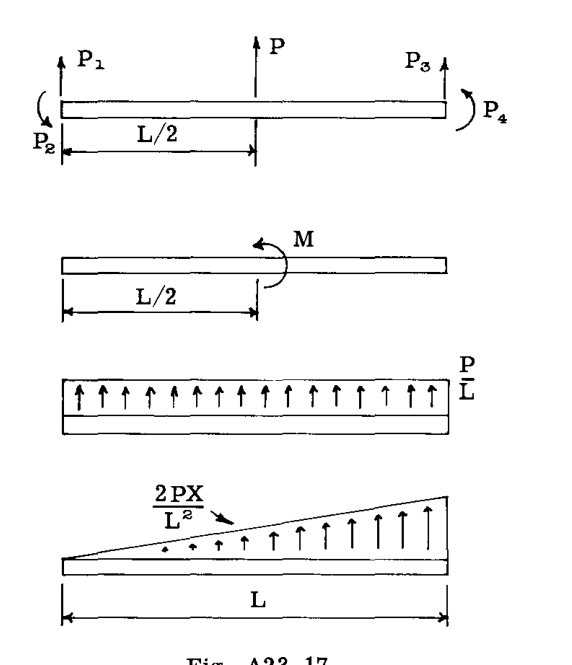

Fig. A23.17

#### 表 A23.5

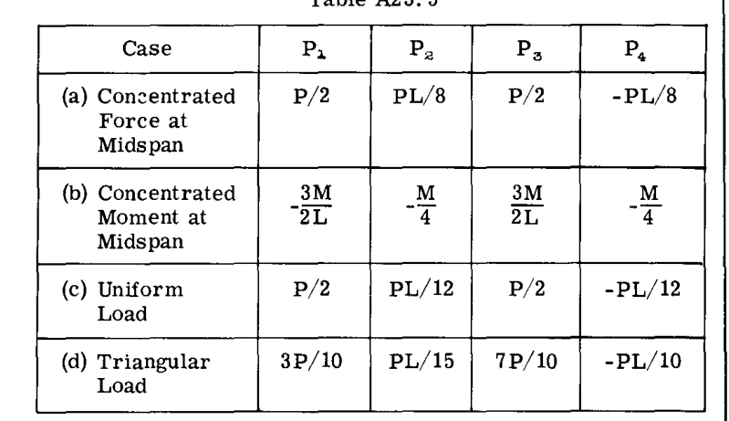

Table A23.5

これらの節点力は、第11章のモーメント分配法で使用される固定端モーメントに関連していることに注意されたい。モーメント $P_2$ と $P_4$ は固定端モーメントであり、反力 $P_1$ と $P_3$ は静力学によって得られる。他の関心のあるケースについては、本書の第11章、表 A11.1 に表示されている情報を参照されたい。そこから適切な節点力を導き出すことができる。表に現れない荷重は、多くの場合、指定されたケースを重ね合わせることによって得られる。

### A23.10 有限要素を用いた構造モデリング

構造モデリングのプロセスは、設計の過程でいくつかの抽象化レベルで発生する。通常、最初は概念モデルがあり、トラス、ケーブル、フレーム、アーチ、シェルなど、多くの可能性の中から作用荷重を伝達するために必要な構造のタイプを選択する。設計図を作成する際には、より詳細なモデルが必要になる。接続やブラケットを詳細にし、利用可能なシートメタルのゲージ、圧延または押し出しセクション、実際の材料特性などに基づいて部材のサイズを決定する必要がある。概念モデルと詳細モデルの両方に関連し、構造を適切に定式化された数学的問題に還元する分析モデルも必要である。数学的問題の解決によって生成された数値は、設計概念を検証し、必要に応じて再設計の合理的な基礎を提供するために使用される。有限要素モデリングは、構造の数学的記述を生成するための一つの方法である。次の2つのセクションは、読者に代表的な有限要素モデルの性質と、それらによって得られる結果の種類を理解してもらうことを目的とした、いくつかの代表的な例題で構成されている。

### 例題4

図 A7.16 のトラス（図 A23.18 に再掲）を再考する。トラスは、ジョイント間でモーメントが伝達されないピン接合構造として定義される。この理想化が満たされることはめったになく、トラスは実際には比較的細長部材で構成されたフレームである。示されている構造をフレームとして再解析し、結果をセクション A7.7 で提示されたトラス解析と比較する。前の問題文には、構造部材の断面特性に関するデータは含まれていなかった。妥当な設計哲学に基づいて、計算値が提供されている。材料をアルミニウムとし、弾性係数 $E = 10^7\text{ psi}$ と仮定すると、部材面積は 表 A7.3 から見つけることができる。典型的な航空機用 I セクションを図 A23.19 に、材料の厚さで表した寸法とともに示す。このセクションについて、以下の関係がある。

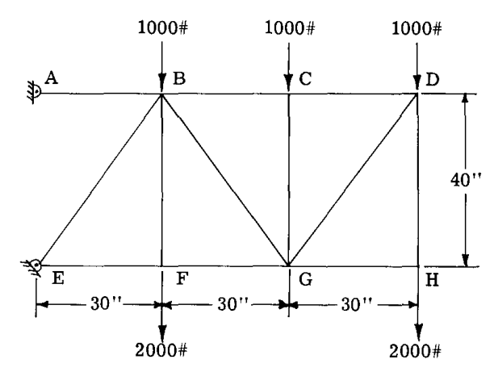

Fig. A23.18

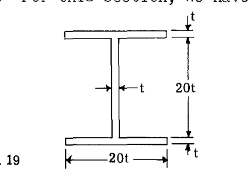

Fig. A23.19

$$\begin{aligned}
A &= 60 t^2 & (75) \\
I &= 5080 t^4 & (76a) \\
\text{or } I &= 1.409 A^2 & (76b)
\end{aligned}$$

これらは 表 A23.6 に与えられた慣性モーメントを計算するために使用されている。

#### 表 A23.6

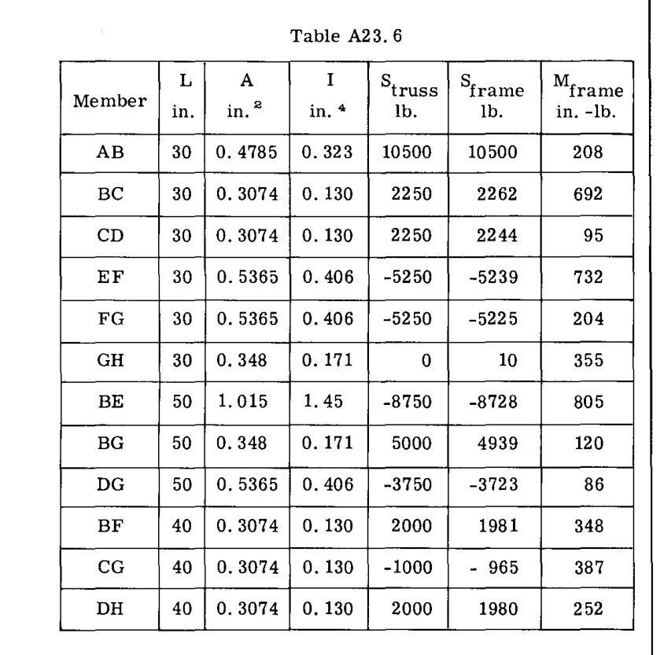

Table A23.6

構造の有限要素モデルが使用され、各部材は $6 \times 6$ の剛性マトリクスによって表されている。この剛性マトリクスは、部材の各端における1つの回転座標と2つの並進座標における力と変位の関係を提供するために、セクション A23.4 のケースAとCの結果を組み合わせることによって見出される。構造内には12の要素があり、8つの節点で接続されている。したがって、ジョイントにおける接続条件により、72の要素座標から24のシステム座標への削減が生じる。最後に、節点AとEにそれぞれ2つの境界条件を適用すると、この解析には20の一般化座標があることがわかる。システムの記述と荷重はデジタルコンピュータに読み込まれ、ガウス消去法を使用して問題を解決するようにプログラムされた。

解析結果は 表 A23.6 に示されている。端部固定を無視することの軸力への影響はわずかである。しかし、外側繊維応力の計算に誘起曲げモーメントを含めると、いくつかの部材で大きな違いが生じる。例えば、部材 BC の最大応力は、トラス解析では $(S/A) = 7320\text{ psi}$ 、フレーム解析では $(S/A) + (Mc/I) = 11540\text{ psi}$ で与えられ、58% の差がある。構造設計者は、この影響の可能性を認識し、分析対象の特定の構造に対するその重要性を検討しなければならない。

### 例題5

図 A23.20 の不静定門型ラーメンを変位法によって解析する。

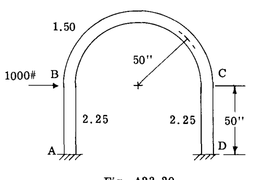

Fig. A23.20

セグメントの相対曲げ剛性は図に示されている。フレームは、セクション A23.4 のケースCで剛性特性が与えられている梁要素を使用してモデル化されている。フレームの曲線部分は、曲線部分の弾性軸上に位置する等間隔の節点を結ぶ 30 本の直線梁要素（弦）によって近似されている。ここで、モデルには 32 の要素が含まれており、接続性と境界条件を考慮した結果、システムには 93 の一般化座標が存在する。コンピュータによる解決が、再びガウス消去法を用いて実行された。チェックとして、点Aにおける計算された反力値が、セクション A8.2.2 で与えられた解析結果と比較された。第8章で得られた方程式は、図 A8.3g, h, i に示されている符号慣例において、 $M = -27650\text{ in.-lb.}$ 、 $V = 801.3\text{ lb.}$ 、 $T = 114.6\text{ lb.}$ の値によって満たされる。比較は 表 A23.7 に示されており、さらに門型ラーメンの曲線部分を近似するために 15、8、4 つの梁要素を使用し、各柱に 1 つの要素を使用した他の 3 つのモデルの結果も示されている。

#### 表 A23.7

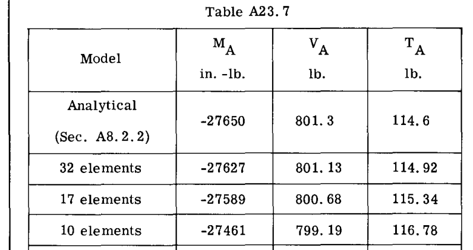

Table A23.7

曲げモーメントは、図 A23.21 のフレーム上の位置の関数としてプロットされている。この問題では曲げが支配的な変形タイプであるため、これは外側繊維応力の空間的変化に対する良好な近似を与える。

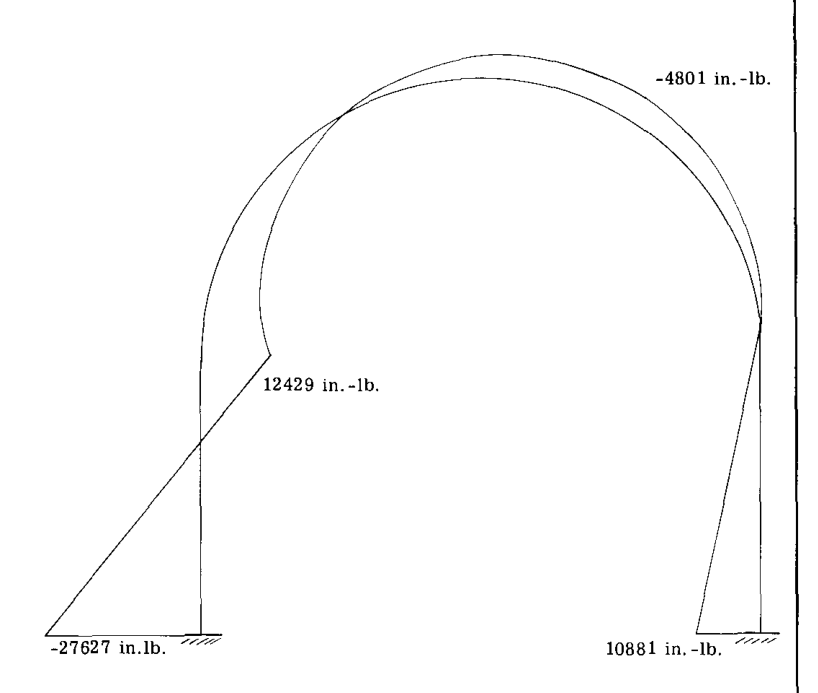

Fig. A23.21

### 例題6

図 A23.22 の厚肉パイプを有限要素を用いてモデル化する。パイプの寸法は $\ell = 24\text{ in.}$ 、 $r_i = 4\text{ in.}$ 、 $r_o = 10\text{ in.}$ である。

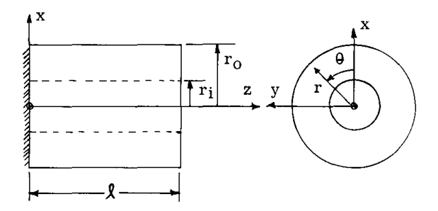

Fig. A23.22

作用剪断荷重は、合力が $x$ 軸に平行な状態でパイプの自由端に作用する。モデルは正方形断面を持つアニュラー（環状）要素で構成されている。典型的な要素とそれに関連する座標は 図 A23.23 に示されている。応力成分も 図 A23.23 で定義されている（より詳細な議論については、第A24章を参照）。解析では、図 A23.24 に示すように、2つの格子サイズが使用されている。

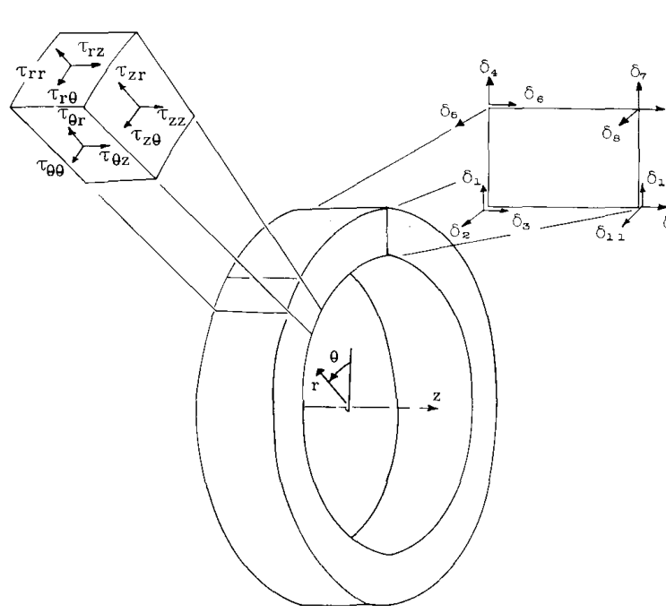

Fig. A23.23

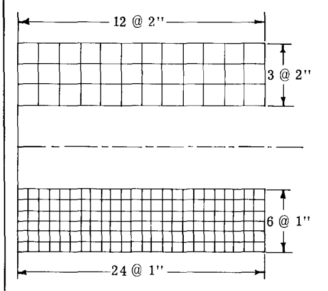

Fig. A23.24

荷重は、自由端の平面に作用する等価な剪断応力（ $\tau_{zr}$ および $\tau_{z\theta}$ ）によって適用される。これらの端部応力は、 $50\text{ psi}$ の均一な垂直剪断応力に相当する $4200\pi\text{ lb.}$ の合力剪断荷重に対して、要素面の中心における理論値と等しく設定された。内部応力分布は弾性理論（7）から導き出され、計算値とともに 図 A23.25 および A23.26 にプロットされている。各ステーションの報告値は、隣接する要素の値の平均を表し、境界面の中心点を基準としている。これらの理論値の導出において、壁における端部条件の性質は無視されている。したがって、2つの結果は中間ステーションでは良好な一致を示すはずであるが、壁の近くでは一致しない。これらの特徴は 図 A23.25 および A23.26 で観察される。壁の近くでは、有限要素モデルは実際の境界条件に基づいて、より現実的な応力値を与える。これは、特にシステムが閉じた形で解析解を排除するのに十分複雑な場合に、しばしば当てはまる。粗い節点格子が、144の要素を使用した洗練された分割で達成されたものと精度において匹敵する結果を与えることに注意されたい。使用する要素数に関する決定は、この種の比較研究の経験に基づいている必要がある。

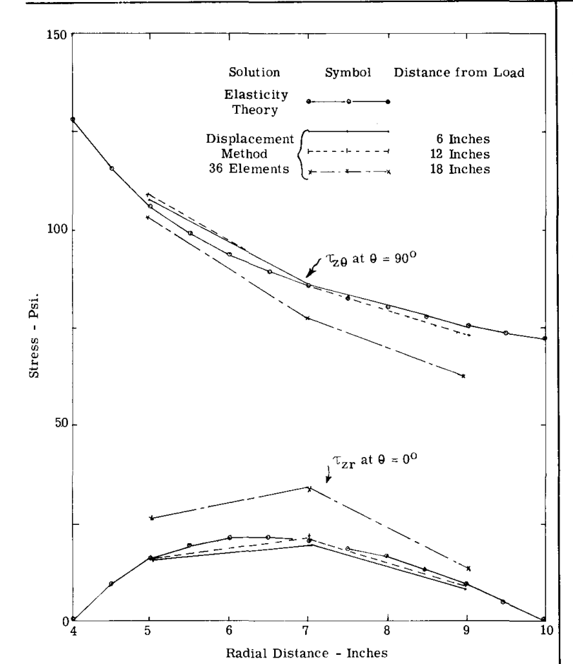

Fig. A23.25

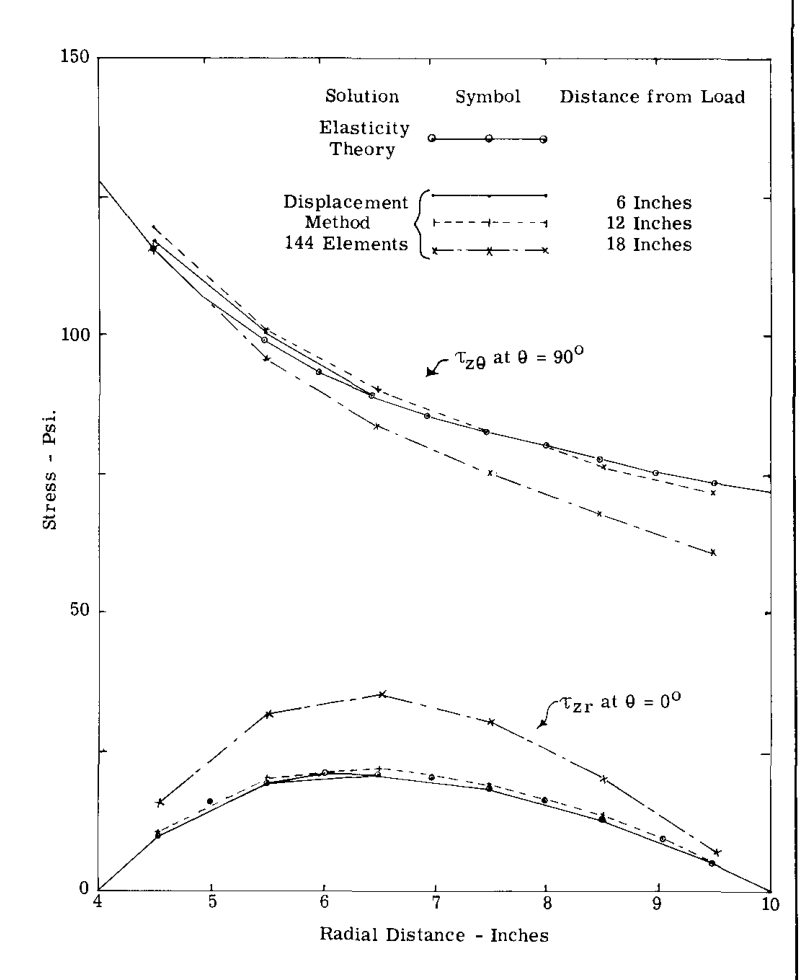

Fig. A23.26

### A23.11 デルタ翼の例題

図 A23.27 の理想化されたデルタ翼構造を解析して、作用荷重の関数としての影響係数と内部応力を決定する。この問題は、解析における部分構造（サブストラクチャ）の使用についても説明する。

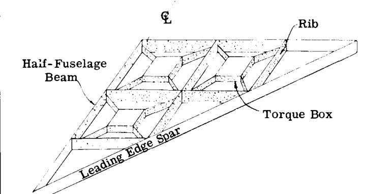

Fig. A23.27

#### 理想化

デルタ翼は、図 A23.28 のように番号が付けられた格子点を持つ格子状の構造に理想化されている。格子番号は後方および外側に向かって増加する。

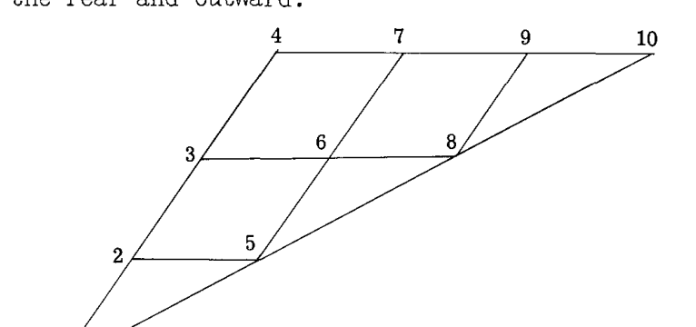

Fig. A23.28

翼の剪断を担うカバーシートのねじり剛性は、スパーとリブの交点を結ぶ四辺形の「トルクボックス」の存在によって考慮されている。格子の例えば点6にコーナーを持つトルクボックスの抵抗（例えば、ボックス 6-7-8-9）は、ボックスが4つのコーナーすべてを同一平面上に維持しようとする傾向の結果である。明らかに、三角形の「ボックス」にはそのような抵抗がないため、図 A23.27 には示されていない。

検討中の構造において、部材 1-2-3-4 は航空機の中心線上に位置する。この部材の曲げ剛性には、半胴体の剛性に加えて「キャリーシュルー構造」の半分が含まれる。この領域における構造のより詳細な表現が一般的に望ましいが、ここで使用されている過度に単純化されたモデルは、処理するデータ量を制限するために採用されている。この領域における構造の理想化に適用できるいくつかの技術は、文献（11）に示されている。

特に有効外皮面積に関する理想化については、Levy（8）によってかなり詳細に議論されている。このフェーズの複雑さは、ここで広範な議論を行うには大きすぎる。簡潔に言えば、Levy の推奨事項は以下の通りである。

1. スパー方向（スパン方向）の外皮は、そのようなスパーのキャップ面積を計算する際に、すべて有効と見なすことができる。この仮定は、もちろん、外皮を座屈させるようなスパン方向の応力が予想される場合には修正される。
2. 流れ方向のリブについては、 $0.362L$ の有効外皮幅（ここで $L$ はリブの長さ）が、各リブキャップと連動して作用すると見なすことができる（図 A23.29a）。
3. 前縁スパーについては、スパー間のスパンの $0.181$ の有効外皮幅が、各スパーセグメントのキャップと連動して作用すると見なすことができる（図 A23.29b）。

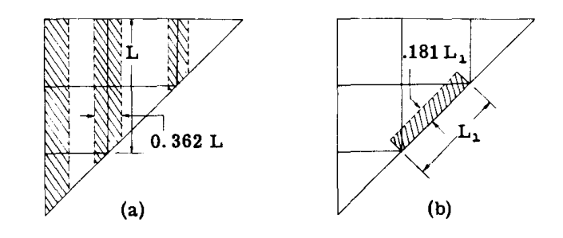

Fig. A23.29

#### 構造特性の要約

理想化後の構造（図 A23.27）の特性は以下のように要約される。

| 代表点 (図 A23.28 参照) | 梁の高さ (インチ) |
| --- | --- |
| 1 | 5.56 |
| 2 | 9.12 |
| 3 | 7.80 |
| 4 | 3.16 |
| 5 | 4.88 |
| 6 | 7.26 |
| 7 | 3.06 |
| 8 | 4.02 |
| 9 | 2.74 |
| 10 | 0.72 |

すべてのカバー外皮厚さ $t = 0.051''$

#### 梁要素の特性

（慣性モーメント（ $\text{in}^4$ ）は、番号が付けられた点の間で線形に変化すると仮定される）

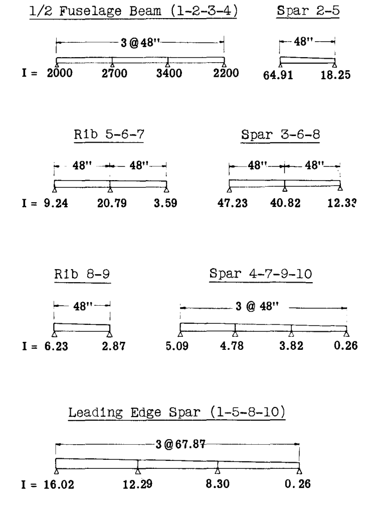

beam elements properties

#### 符号慣例

図 A23.28 の格子番号付けスキームに関連して採用された符号慣例は以下の通りである。

要素力、 $P_m$

- 節点における横力、
  - $+$ 上向き
- または、節点におけるピッチングモーメント、
  - $+$ 機首下げ
- または、節点におけるローリングモーメント、
  - $+$ 右翼下げ
- または、斜め部材上のモーメント、
  - その部材の平面内で作用し、部材をそのジョイント番号が左から右に増加するように見たときに $+$ 反時計回り。

要素変位、 $\delta_m$

- 対応する力と同じ番号および符号慣例に従う。

上記の符号慣例により、ジョイント番号が左から右に増加するように見られる梁要素（スパーまたはリブ）は、セクション A23.4 の梁要素の表と互換性のある方向で力と変位を持つことになる。

#### 要素剛性の計算

次に、梁セグメントとトルクボックスについて要素剛性マトリクスが計算される。梁セグメントについては、セクション A23.4 のケースDの方程式が使用される。トルクボックスについては、以下で明示的に処理される。

#### 梁セグメント剛性マトリクス

梁セグメントについては、格子点 2 と 5 の間のスパーが計算を代表している。先に与えられた梁要素の特性、および 図 A7.34C から、

$$\begin{aligned}
I_i / I_j &= 0.281 \\
\phi_{11} &= 0.670 \\
\phi_{ij} &= 0.480 \quad \phi_{ij}/2 = 0.240 \\
\phi_{jj} &= 0.370
\end{aligned}$$

すると、

$$D_{2-5} = (0.670)(0.370) - (0.240)^2 = 0.1903$$

であり、

$$[k_{2-5}] = \begin{bmatrix} 0.003954 & 0.1136 & -0.003954 &
0.07616 \\ 0.1136 & 4.015 & -0.1136 & 1.438 \\ -0.003954
& -0.1136 & 0.003954 & -0.07616 \\ 0.07616 & 1.438 &
-0.07616 & 2.217 \end{bmatrix}$$

ここで、便宜上 $E = 1$ としている。梁要素（スパー 2-5）の力と変位は正の方向で適用され、梁要素を格子番号が左から右に増加するように見たときに、セクション A23.4 のケースDのように数値順に配列されることが理解される。

同様に、残りの14の梁セグメント（スパー、リブ、および前縁スパーセグメント）の要素剛性が計算される。それらは、スペースの節約のためにここでは表にまとめられていない。

#### トルクボックス剛性マトリクス

トルクボックスの場合、剛性マトリクスは直接計算できる（それらは静定である）。以下の近似解析は、ほとんどのトルクボックスに対して満足のいくものとして提案される。極端な形状を持つボックスについては、より詳細な解析が適切かもしれない。代替方法は文献（8）に提示されており、適切な議論は文献（12）に見出される。カバー外皮の完全に異なる処理は文献（10）に与えられている。

図 A23.30 の四辺形ボックスを考える。

[figure not shown]

Fig. A23.30

この当面の解析の目的のために、ボックスは $r-s$ のような一端から片持ち支持されていると見なされる。弾性軸（e.a.）は長辺の中間に存在すると仮定され、「有効固定端」が採用される。ボックス上のトルクは、

$$T = P_m b_m - P_n b_n$$